# Weight Lifting Exercises: prediction of how well the exercise was done

## Exploratory analysis

Load required packages. Download and read data. Look at the structure of the training dataset.

```r
library(caret); library(randomForest); library(ggplot2); library(gridExtra)
if(!file.exists("pml-training.csv")){
  trainURL <- "https://d396qusza40orc.cloudfront.net/predmachlearn/pml-training.csv"
  download.file(trainURL, destfile = "pml-training.csv")}
if(!file.exists("pml-testing.csv")){
  testURL <- "https://d396qusza40orc.cloudfront.net/predmachlearn/pml-testing.csv"
  download.file(testURL, destfile = "pml-testing.csv")}
pml_train <- read.csv("pml-training.csv", na.strings = c("NA", ""))
pml_test <- read.csv("pml-testing.csv", na.strings = c("NA", ""))
#str(pml_train)
```

After running `str(pml_train)` (commented out because the output is long), we know that there are 160 variables, some of them are averages, maxima, minima etc, thus they are NAs almost everywhere. So we get rid of them.

```r
pml_train <- pml_train[, colSums(is.na(pml_train)) < 1]
```

Next, the first 7 variables seem to be auxiliary and unnessessary for the model. From the figure below (it’s just one figure with 7 plots :) ) one can see that only the first variable, `X` correlates with the `classe` outcome. But the fact that `X` has almost perfect correlation with `classe` only means that the rows are sorted by class, so variable `X` should not be used when building a model.

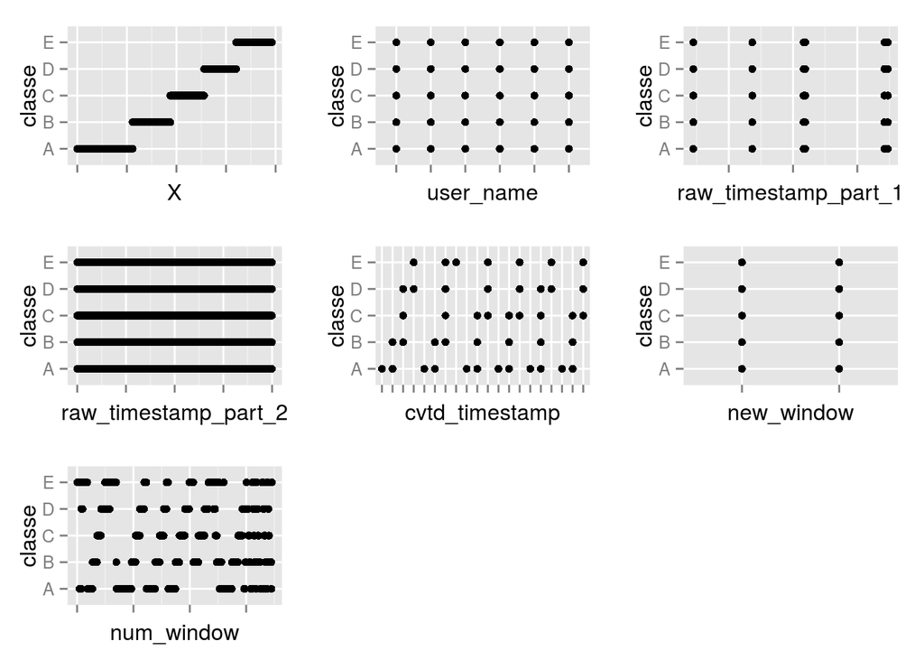

```r
p1 <- ggplot(pml_train, aes(y = classe, x = X)) + geom_point(stat="identity") +
  labs(x = "X", y = "classe") + theme(axis.text.x=element_blank())
p2 <- ggplot(pml_train, aes(y = classe, x = user_name)) + geom_point(stat="identity") +
  labs(x = "user_name", y = "classe") + theme(axis.text.x=element_blank())
p3 <- ggplot(pml_train, aes(y = classe, x = raw_timestamp_part_1)) + geom_point(stat="identity") +
  labs(x = "raw_timestamp_part_1", y = "classe") + theme(axis.text.x=element_blank())
p4 <- ggplot(pml_train, aes(y = classe, x = raw_timestamp_part_2)) + geom_point(stat="identity") +
  labs(x = "raw_timestamp_part_2", y = "classe") + theme(axis.text.x=element_blank())
p5 <- ggplot(pml_train, aes(y = classe, x = cvtd_timestamp)) + geom_point(stat="identity") +
  labs(x = "cvtd_timestamp", y = "classe") + theme(axis.text.x=element_blank())
p6 <- ggplot(pml_train, aes(y = classe, x = new_window)) + geom_point(stat="identity") +
  labs(x = "new_window", y = "classe") + theme(axis.text.x=element_blank())
p7 <- ggplot(pml_train, aes(y = classe, x = num_window)) + geom_point(stat="identity") +
  labs(x = "num_window", y = "classe") + theme(axis.text.x=element_blank())
fig1 <- grid.arrange(p1, p2, p3, p4, p5, p6, p7, nrow = 3)
```

So, now our training set `pml_train` has 60 variables, the 60-th one is the outcome, and 8:59 are used as predictors.

## Model

Try models from the following classes: simple tree model, linear discriminant analysis, boosting, and random forest (with default settings). After each fit print its user time and best accuracy.

```r
set.seed(2807540)
tree_fit <- train(x = pml_train[8:59], y = pml_train$classe, method = "rpart")
print(data.frame(user_time = tree_fit$times[[1]][[1]], best_accuracy = tree_fit$results[[2]][[as.integer(row.names(tree_fit$bestTune))]]))
```

```
##   user_time best_accuracy
## 1    19.741      0.514341
```

```r
lda_fit <- train(x = pml_train[8:59], y = pml_train$classe, method = "lda")
print(data.frame(user_time = lda_fit$times[[1]][[1]], best_accuracy = lda_fit$results[[2]][[as.integer(row.names(lda_fit$bestTune))]]))
```

```
##   user_time best_accuracy
## 1    14.642     0.7027026
```

```r
boost_fit <- train(x = pml_train[8:59], y = pml_train$classe, method = "gbm", verbose =F)
print(data.frame(user_time = boost_fit$times[[1]][[1]], best_accuracy = boost_fit$results[[5]][[as.integer(row.names(boost_fit$bestTune))]]))
```

```
##   user_time best_accuracy
## 1  2023.877      0.959575
```

```r
rf_fit <- train(x = pml_train[8:59], y = pml_train$classe, method = "rf")
print(data.frame(user_time = rf_fit$times[[1]][[1]], best_accuracy = rf_fit$results[[2]][[as.integer(row.names(rf_fit$bestTune))]]))
```

```
##   user_time best_accuracy
## 1  5719.962     0.9929607
```

From the above summaries, simple tree model is (not surprisingly) very inaccurate, linear discriminant analysis is better but still not accurate enough. Boosting and random forest are both very good. Random forest model is more computationally demanding, but also more accurate. Normally I would choose boosting, but since for this project we need to submit correct test results, I decided to go with the most accurate model - random forest. Also, from now on we will call `randomForest` function directly instead of using `train(... method = "rf" ...)` since it runs much faster. So, here is our final model:

```r
set.seed(241291)
rf_fit_final <- randomForest(x = pml_train[8:59], y = pml_train$classe)
rf_fit_final
```

```
##
## Call:
##  randomForest(x = pml_train[8:59], y = pml_train$classe)
##                Type of random forest: classification
##                      Number of trees: 500
## No. of variables tried at each split: 7
##
##         OOB estimate of  error rate: 0.27%
## Confusion matrix:
##      A    B    C    D    E class.error
## A 5580    0    0    0    0 0.000000000
## B   11 3783    3    0    0 0.003687121
## C    0   10 3412    0    0 0.002922268
## D    0    0   21 3194    1 0.006840796
## E    0    0    2    4 3601 0.001663432
```

## Cross-validation

Do a 5-fold cross-validation to test the accuracy of the final model and estimate out-of-sample error. Each element of the `folds` list contains indeces of the corresponding 5 test sets. We create a function `cv`, which does the following:  
1. builds a model using the rows that are not test rows;  
2. predicts and constructs confusion matrix for the corresponding test set.  
The function is then applied to each element of the `folds` list.

```r
set.seed(2431)
nfolds <- 5
folds <- createFolds(y = pml_train$classe, k = nfolds, list = T, returnTrain = F)
cv <- function(fold) {
  cv_fit <- randomForest(x = pml_train[-fold, 8:59], y = pml_train[-fold, 60])
  confusionMatrix(pml_train[fold, 60], predict(cv_fit, pml_train[fold,]))
}
cv_confMat <- lapply(folds, cv)
cv_accuracy <- sapply(cv_confMat, function(fold){fold$overall[1]})
print(cv_accuracy)
```

```
## Fold1.Accuracy Fold2.Accuracy Fold3.Accuracy Fold4.Accuracy Fold5.Accuracy
##      0.9949058      0.9969411      0.9964340      0.9943935      0.9951568
```

```r
mean(cv_accuracy)
```

```
## [1] 0.9955662
```